# Lösungen: Statistische Tests in R

Author

Euer Team der Statistik II Übung

**Hinweis**

Die Frage 1.8 (unter t-Tests) war noch fälschlicherweise im Übungsblatt. Die Interpretation ist bereits mit Frage 1.6 abgedeckt.

# Teil 1: Programmierteil in R

Hier werden alle notwendigen Bibliotheken geladen.

```r
library(car)
```

## Aufgabe 1.1: Einlesen des Datensatzes

Mit diesem Befehl laden wir den Datensatz. Wichtig ist, das wir im richtigen Arbeitsverzeichnis sind. Das geht mit `setwd("hier kommt der Pfad rein")`

```r
load("digitales_lernen.RData")
```

## Aufgabe 1.2 – Überblick über den Datensatz

```r
head(df)
```

```
  klausurnote  lernmethode vorwissen motivation_vor motivation_nach
1          66      digital   niedrig              5               5
2          70      digital   niedrig              7               8
3          64      digital      hoch              5               6
4          65      digital      hoch              7               8
5          61 traditionell   niedrig              8               8
6          70 traditionell      hoch              8               9
  lernzeit_gesamt geschlecht gruppe
1              26   weiblich      A
2              49   weiblich      A
3              15   männlich      A
4              16   weiblich      B
5              34   weiblich      B
6              41   weiblich      B
```

```r
summary(df)
```

```
  klausurnote          lernmethode   vorwissen  motivation_vor motivation_nach
 Min.   :49.00   digital     :49   hoch   :47   Min.   :3.00   Min.   : 2.00
 1st Qu.:59.75   traditionell:51   niedrig:53   1st Qu.:5.00   1st Qu.: 5.00
 Median :65.00                                  Median :6.00   Median : 6.00
 Mean   :64.98                                  Mean   :5.98   Mean   : 6.38
 3rd Qu.:70.00                                  3rd Qu.:7.00   3rd Qu.: 8.00
 Max.   :86.00                                  Max.   :9.00   Max.   :10.00
 lernzeit_gesamt    geschlecht gruppe
 Min.   :10.00   männlich:45   A:43
 1st Qu.:23.00   weiblich:55   B:57
 Median :30.00
 Mean   :30.66
 3rd Qu.:36.50
 Max.   :61.00
```

Interpretation:

- Der Datensatz enthält 100 Beobachtungen (Studierende) mit 8 Variablen
- Klausurnoten liegen zwischen 49 und 86 Punkten (Mittelwert: 64.98)
- 49 Studierende lernten digital, 51 traditionell

## Aufgabe 1.3 – Geschlechterverteilung und Klausurnoten

```r
table(df$geschlecht)
```

```
männlich weiblich
      45       55
```

```r
# Mittlere Punkte in der Abschlussklausur der Männer
mean(df$klausurnote[df$geschlecht == "männlich"])
```

```
[1] 64.8
```

```r
# Mittlere Punkte in der Abschlussklausur der Frauen
mean(df$klausurnote[df$geschlecht == "weiblich"])
```

```
[1] 65.12727
```

Die Geschlechterverteilung ist relativ ausgeglichen (45 männlich, 55 weiblich) und die mittleren Punktezahlen vergleichbar.

Hier noch eine kürzere alternative Variante zur Berechnung der Mittelwerte:

```r
aggregate(klausurnote ~ geschlecht, data = df, FUN = mean)
```

```
  geschlecht klausurnote
1   männlich    64.80000
2   weiblich    65.12727
```

## Aufgabe 1.4 – Normalverteilung

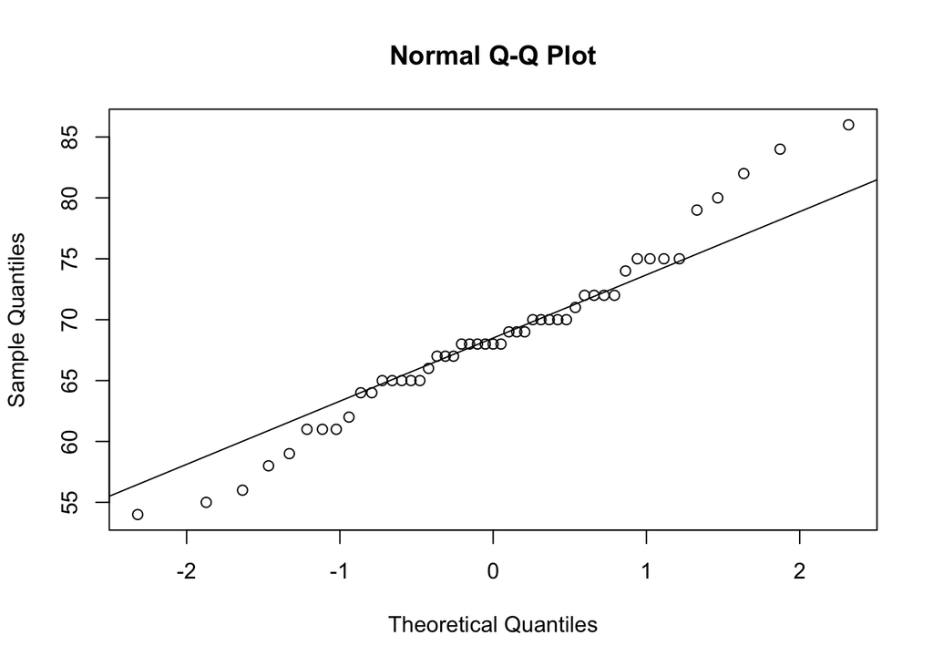

```r
qqnorm(df$klausurnote[df$lernmethode == "digital"])
qqline(df$klausurnote[df$lernmethode == "digital"])
```

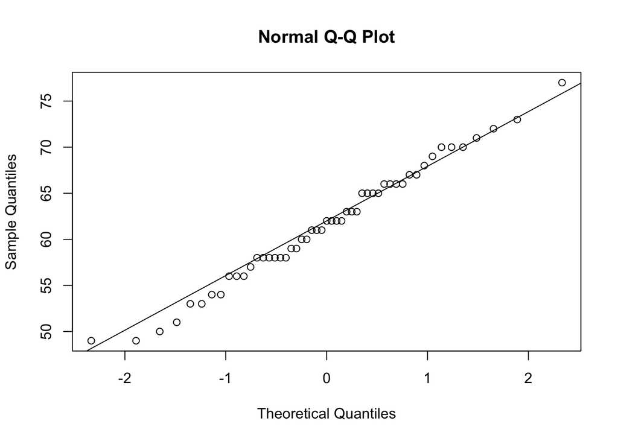

```r
qqnorm(df$klausurnote[df$lernmethode == "traditionell"])
qqline(df$klausurnote[df$lernmethode == "traditionell"])
```

```r
shapiro.test(df$klausurnote[df$lernmethode == "digital"])
```

```
    Shapiro-Wilk normality test

data:  df$klausurnote[df$lernmethode == "digital"]
W = 0.97484, p-value = 0.3728
```

```r
shapiro.test(df$klausurnote[df$lernmethode == "traditionell"])
```

```
    Shapiro-Wilk normality test

data:  df$klausurnote[df$lernmethode == "traditionell"]
W = 0.98765, p-value = 0.8702
```

**Interpretation der Normalverteilungsprüfung:**

- Q-Q-Plots: Die Punkte liegen größtenteils auf oder nahe der Geraden → Hinweis auf Normalverteilung
- Shapiro-Wilk-Tests: Digital: p = 0.373 > 0.05 → H₀ (Normalverteilung) nicht verworfen
- Shapiro-Wilk-Tests: Traditionell: p = 0.870 > 0.05 → H₀ (Normalverteilung) nicht verworfen
- Fazit: Die Normalverteilungsannahme ist für beide Gruppen erfüllt → t-Test ist angemessen

## Aufgabe 1.5 – Varianzhomogenität

```r
leveneTest(klausurnote ~ lernmethode, data = df)
```

```
Levene's Test for Homogeneity of Variance (center = median)
      Df F value Pr(>F)
group  1  0.0179  0.894
      98
```

## Aufgabe 1.6 – t-Test

```r
t.test(klausurnote ~ lernmethode, data = df, var.equal = TRUE, alternative = "greater")
```

```
    Two Sample t-test

data:  klausurnote by lernmethode
t = 5.1259, df = 98, p-value = 7.446e-07
alternative hypothesis: true difference in means between group digital and group traditionell is greater than 0
95 percent confidence interval:
 4.652532      Inf
sample estimates:
     mean in group digital mean in group traditionell
                  68.48980                   61.60784
```

**Interpretation des t-Tests:** Die digitale Lernmethode ist der traditionellen Methode **signifikant überlegen** (68,49 vs. 61,61 Punkte).

## Aufgabe 1.7 – t-Verteilung visualisieren

Die Visualisierung solltet ihr am besten auf einem Blatt machen. Ziel der Aufagbe ist es nicht es per Code zu visualisieren.

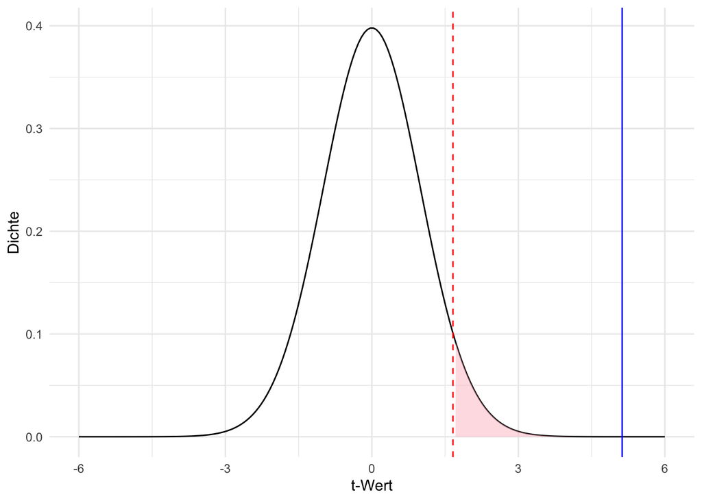

**Interpretation der Visualisierung:**

- **Rote gestrichelte Linie**: Kritischer t-Wert (t_krit ≈ 1.66) bei α = 0.05
- **Rosa schattierter Bereich**: Ablehnungsbereich der Nullhypothese (5% der Fläche)
- **Blaue Linie**: Empirischer t-Wert (t_emp = 5.126)

Der **empirische t-Wert liegt weit im Ablehnungsbereich** → Die Wahrscheinlichkeit, diesen oder einen extremeren Wert unter H₀ zu beobachten, ist **extrem gering** (< 0.001%). Dies bestätigt die **Ablehnung der Nullhypothese**.

## Aufgabe 1.8 – ANOVA

```r
anova_model <- aov(motivation_nach ~ lernmethode * vorwissen, data = df)
summary(anova_model)
```

```
                      Df Sum Sq Mean Sq F value   Pr(>F)
lernmethode            1  50.09   50.09  23.329 5.16e-06 ***
vorwissen              1  64.82   64.82  30.189 3.22e-07 ***
lernmethode:vorwissen  1   2.53    2.53   1.177    0.281
Residuals             96 206.12    2.15
---
Signif. codes:  0 '***' 0.001 '**' 0.01 '*' 0.05 '.' 0.1 ' ' 1
```

**Interpretation der zweifaktoriellen ANOVA:**

- **Lernmethode (F = 23.329, p < 0.001):** Es gibt einen signifikanten Haupteffekt der Lernmethode auf die Motivation nach der Intervention. Traditionelle und digitale Lernmethoden unterscheiden sich systematisch in ihrer Wirkung auf die Motivation.
- **Vorwissen (F = 30.189, p < 0.001):** Der Haupteffekt des Vorwissens ist ebenfalls signifikant. Studierende mit niedrigem und hohem Vorwissen unterscheiden sich in ihrer Motivation nach der Intervention.
- **Lernmethode × Vorwissen (F = 1.177, p = 0.281):** Die Interaktion ist nicht signifikant. Die Wirkung der Lernmethoden auf die Motivation ist unabhängig vom Vorwissensstand der Studierenden.

Sowohl die Lernmethode als auch das Vorwissen beeinflussen die Motivation nach der Intervention. Da keine Interaktion vorliegt, wirken beide Faktoren unabhängig voneinander.

## Aufgabe 1.9 – Interaktionsplot

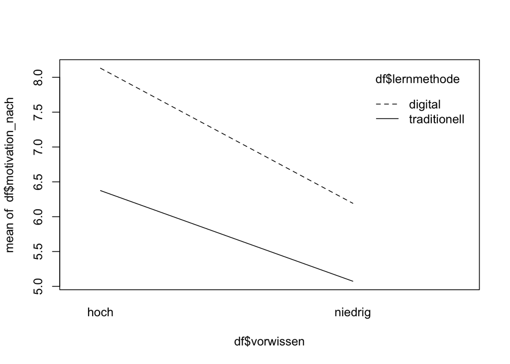

```r
interaction.plot(df$vorwissen, df$lernmethode, df$motivation_nach)
```

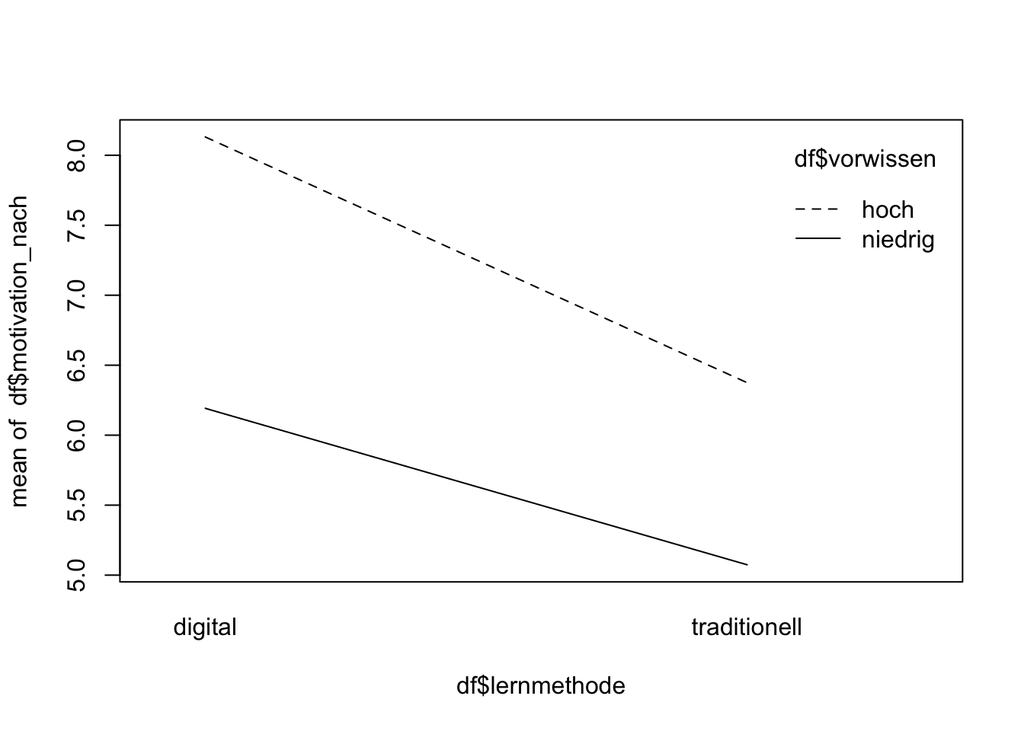

```r
interaction.plot(df$lernmethode, df$vorwissen, df$motivation_nach)
```

**Interpretation des Interaktionsplots:** Es liegt eine **ordinale Interaktion** vor: Die beiden Linien verlaufen **nicht parallel**, schneiden sich jedoch **nicht**.

## Aufgabe 1.10 – Voraussetzungen der Regression

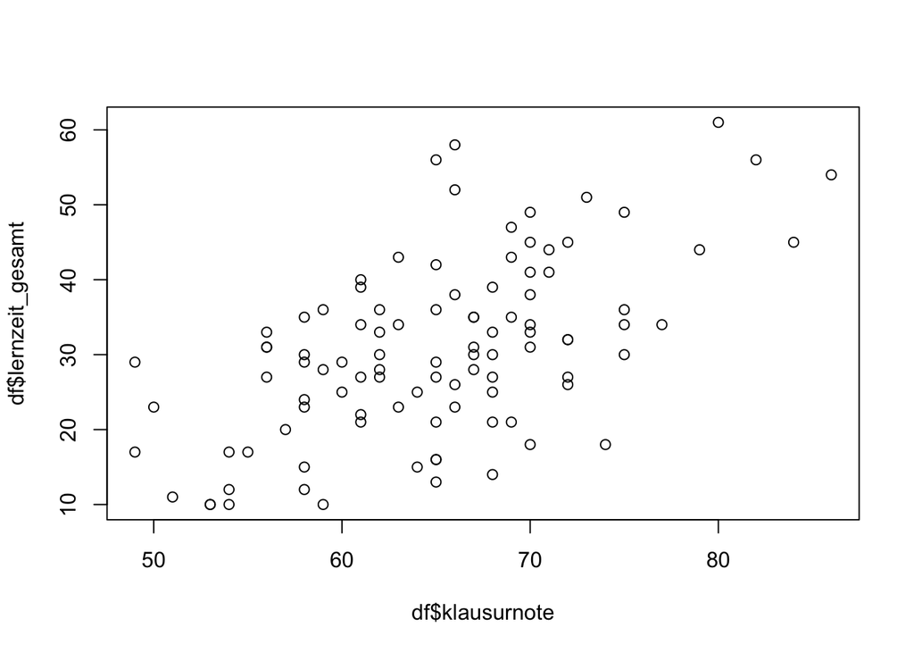

```r
plot(df$klausurnote, df$lernzeit_gesamt)
```

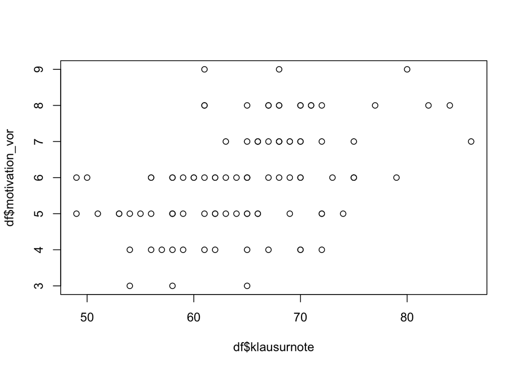

```r
plot(df$klausurnote, df$motivation_vor)
```

**Interpretation der Linearitätsprüfung:** Es sind keine starken Abweichungen in Form z. B. einer quadratischen Funktion zu erkennen. Es kann somit von einem **linearen Zusammenhang ausgegangen werden** (auch wenn er vielleicht keinen Einfluss hat).

## Aufgabe 1.11 – Multiple Regression

```r
model <- lm(klausurnote ~ lernzeit_gesamt + motivation_vor + geschlecht, data = df)
summary(model)
```

```
Call:
lm(formula = klausurnote ~ lernzeit_gesamt + motivation_vor +
    geschlecht, data = df)

Residuals:
     Min       1Q   Median       3Q      Max
-15.6179  -4.3898  -0.1524   4.1919  13.6965

Coefficients:
                   Estimate Std. Error t value Pr(>|t|)
(Intercept)        49.80097    2.69322  18.491  < 2e-16 ***
lernzeit_gesamt     0.30690    0.06269   4.895 3.96e-06 ***
motivation_vor      0.93852    0.52012   1.804   0.0743 .
geschlechtweiblich  0.28568    1.23780   0.231   0.8180
---
Signif. codes:  0 '***' 0.001 '**' 0.01 '*' 0.05 '.' 0.1 ' ' 1

Residual standard error: 6.111 on 96 degrees of freedom
Multiple R-squared:  0.3597,    Adjusted R-squared:  0.3396
F-statistic: 17.97 on 3 and 96 DF,  p-value: 2.454e-09
```

**Interpretation des Regressionsmodells:**

- **Intercept**: Eine männliche Person mit einem Wert von 0 für `lernzeit_gesamt` und `motivation_vor` hat im Mittel einen Wert von 49,8 in der Klausur. Je nachdem, wie diese beiden Variablen gemessen wurden, kann dies eine sinnvolle Aussage sein, muss es aber nicht.
- **Lernzeit_gesamt**: b *(unstandardisierte Steigung)* = 0.307, p < 0.001 → **signifikant**: Pro zusätzliche Stunde Lernzeit steigt die Klausurnote im Mittel um **0.31 Punkte**
- Die anderen Effekte sind nicht signifikant.
- **R² = 0.3597** → Das Modell erklärt **36% der Varianz** in den Klausurnoten

## Aufgabe 1.12 – Vorhersage

```r
49.80097 + 50 * 0.30690 + 7 * 0.93852 + 1 * 0.28568
```

```
[1] 72.00129
```

Für eine **weibliche** Studentin mit:

- **50 Stunden** Lernzeit
- **Motivation 7** (vor der Intervention)

**Vorhergesagte Klausurnote: 72.0 Punkte**

**Aufschlüsselung der Beiträge:**

- **Intercept** (Grundwert): 49.8 Punkte
- **Lernzeit-Effekt**: 50 × 0.31 = 15.3 Punkte
- **Motivations-Effekt**: 7 × 0.94 = 6.6 Punkte
- **Geschlechts-Effekt**: 1 × 0.29 = 0.3 Punkte